# Risk Factor Analysis

## Outcome Variable

**Outcome Variable:** whz

## Predictor Variables

**Intervention Variable:** fhtcm

**Adjustment Set:**

- arm
- W_mage
- W_fage
- meducyrs
- feducyrs
- W_mhtcm
- W_mwtkg
- W_mbmi
- single
- delta_W_mage
- delta_W_fage
- delta_meducyrs
- delta_feducyrs
- delta_W_mhtcm
- delta_W_mwtkg
- delta_W_mbmi
- delta_single

## Stratifying Variables

The analysis was stratified on these variable(s):

- agecat
- studyid
- country

## Data Summary

| agecat | studyid | country | fhtcm | n_cell | n | outcome_variable |
| --- | --- | --- | --- | --- | --- | --- |
| Birth | COHORTS | GUATEMALA | >=167 cm | 26 | 192 | whz |
| Birth | COHORTS | GUATEMALA | <162 cm | 112 | 192 | whz |
| Birth | COHORTS | GUATEMALA | [162-167) cm | 54 | 192 | whz |
| Birth | Keneba | GAMBIA | >=167 cm | 733 | 1114 | whz |
| Birth | Keneba | GAMBIA | <162 cm | 83 | 1114 | whz |
| Birth | Keneba | GAMBIA | [162-167) cm | 298 | 1114 | whz |
| Birth | PROBIT | BELARUS | >=167 cm | 11672 | 12461 | whz |
| Birth | PROBIT | BELARUS | <162 cm | 168 | 12461 | whz |
| Birth | PROBIT | BELARUS | [162-167) cm | 621 | 12461 | whz |
| Birth | SAS-CompFeed | INDIA | >=167 cm | 312 | 657 | whz |
| Birth | SAS-CompFeed | INDIA | <162 cm | 159 | 657 | whz |
| Birth | SAS-CompFeed | INDIA | [162-167) cm | 186 | 657 | whz |
| 6 months | COHORTS | GUATEMALA | >=167 cm | 44 | 336 | whz |
| 6 months | COHORTS | GUATEMALA | <162 cm | 198 | 336 | whz |
| 6 months | COHORTS | GUATEMALA | [162-167) cm | 94 | 336 | whz |
| 6 months | Keneba | GAMBIA | >=167 cm | 979 | 1510 | whz |
| 6 months | Keneba | GAMBIA | <162 cm | 113 | 1510 | whz |
| 6 months | Keneba | GAMBIA | [162-167) cm | 418 | 1510 | whz |
| 6 months | PROBIT | BELARUS | >=167 cm | 11142 | 11891 | whz |
| 6 months | PROBIT | BELARUS | <162 cm | 156 | 11891 | whz |
| 6 months | PROBIT | BELARUS | [162-167) cm | 593 | 11891 | whz |
| 6 months | SAS-CompFeed | INDIA | >=167 cm | 370 | 807 | whz |
| 6 months | SAS-CompFeed | INDIA | <162 cm | 193 | 807 | whz |
| 6 months | SAS-CompFeed | INDIA | [162-167) cm | 244 | 807 | whz |
| 6 months | SAS-FoodSuppl | INDIA | >=167 cm | 102 | 371 | whz |
| 6 months | SAS-FoodSuppl | INDIA | <162 cm | 148 | 371 | whz |
| 6 months | SAS-FoodSuppl | INDIA | [162-167) cm | 121 | 371 | whz |
| 24 months | COHORTS | GUATEMALA | >=167 cm | 72 | 532 | whz |
| 24 months | COHORTS | GUATEMALA | <162 cm | 311 | 532 | whz |
| 24 months | COHORTS | GUATEMALA | [162-167) cm | 149 | 532 | whz |
| 24 months | Keneba | GAMBIA | >=167 cm | 823 | 1298 | whz |
| 24 months | Keneba | GAMBIA | <162 cm | 96 | 1298 | whz |
| 24 months | Keneba | GAMBIA | [162-167) cm | 379 | 1298 | whz |
| 24 months | PROBIT | BELARUS | >=167 cm | 3386 | 3608 | whz |
| 24 months | PROBIT | BELARUS | <162 cm | 52 | 3608 | whz |
| 24 months | PROBIT | BELARUS | [162-167) cm | 170 | 3608 | whz |

The following strata were considered:

- agecat: 24 months, studyid: COHORTS, country: GUATEMALA
- agecat: 24 months, studyid: Keneba, country: GAMBIA
- agecat: 24 months, studyid: PROBIT, country: BELARUS
- agecat: 6 months, studyid: COHORTS, country: GUATEMALA
- agecat: 6 months, studyid: Keneba, country: GAMBIA
- agecat: 6 months, studyid: PROBIT, country: BELARUS
- agecat: 6 months, studyid: SAS-CompFeed, country: INDIA
- agecat: 6 months, studyid: SAS-FoodSuppl, country: INDIA
- agecat: Birth, studyid: COHORTS, country: GUATEMALA
- agecat: Birth, studyid: Keneba, country: GAMBIA
- agecat: Birth, studyid: PROBIT, country: BELARUS
- agecat: Birth, studyid: SAS-CompFeed, country: INDIA

## Methods Detail

We’re interested in the causal parameters $E[Y_a]$ for all values of $a \in \mathcal{A}$. These parameters represent the mean outcome if, possibly contrary to fact, we intervened to set all units to have $A=a$. Under the randomization and positivity assumptions, these are identified by the statistical parameters $\psi_a=E_W[E_{Y|A,W}(Y|A=a,W)]$. In addition, we’re interested in the mean of $Y$, $E[Y]$ under no intervention (the observed mean). We will estimate these parameters by using SuperLearner to fit the relevant likelihood factors – $E_{Y|A,W}(Y|A=a,W)$ and $p(A=a|W)$, and then updating our likelihood fit using a joint TMLE.

For unadjusted analyses ($W=\{\}$), initial likelihoods were estimated using Lrnr_glm to estimate the simple $E(Y|A)$ and Lrnr_mean to estimate $p(A)$. For adjusted analyses, a small library containing Lrnr_glmnet, Lrnr_xgboost, and Lrnr_mean was used.

Having estimated these parameters, we will then use the delta method to estimate relative risks and attributable risks relative to a prespecified baseline level of $A$.

# Results Detail

## Results Plots

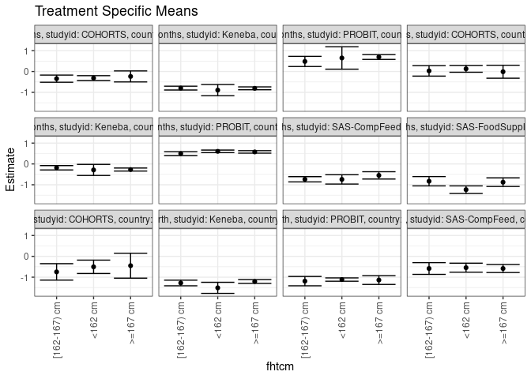

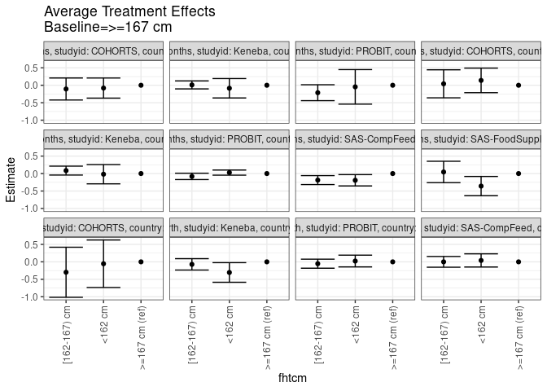

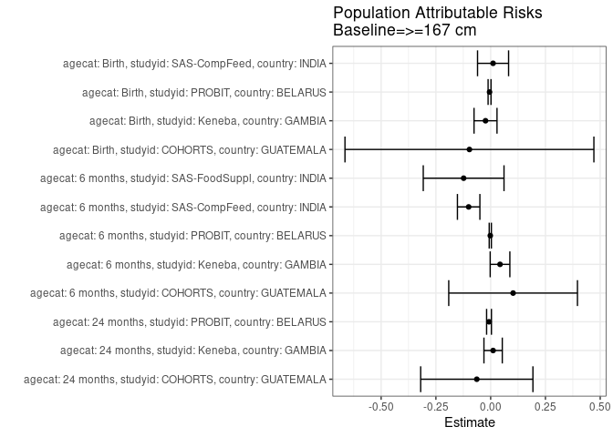

## Results Table

### Parameter: TSM

| agecat | studyid | country | intervention_level | baseline_level | estimate | ci_lower | ci_upper |
| --- | --- | --- | --- | --- | --- | --- | --- |
| Birth | COHORTS | GUATEMALA | >=167 cm | NA | -0.4481118 | -1.0460889 | 0.1498653 |
| Birth | COHORTS | GUATEMALA | <162 cm | NA | -0.5026787 | -0.8243660 | -0.1809915 |
| Birth | COHORTS | GUATEMALA | [162-167) cm | NA | -0.7463786 | -1.1412470 | -0.3515102 |
| Birth | Keneba | GAMBIA | >=167 cm | NA | -1.2069152 | -1.2979979 | -1.1158325 |
| Birth | Keneba | GAMBIA | <162 cm | NA | -1.5114855 | -1.7770308 | -1.2459403 |
| Birth | Keneba | GAMBIA | [162-167) cm | NA | -1.2788477 | -1.4137542 | -1.1439413 |
| Birth | PROBIT | BELARUS | >=167 cm | NA | -1.1368216 | -1.3479293 | -0.9257140 |
| Birth | PROBIT | BELARUS | <162 cm | NA | -1.1137366 | -1.1933837 | -1.0340895 |
| Birth | PROBIT | BELARUS | [162-167) cm | NA | -1.1897994 | -1.4145872 | -0.9650117 |
| Birth | SAS-CompFeed | INDIA | >=167 cm | NA | -0.5842626 | -0.7776482 | -0.3908771 |
| Birth | SAS-CompFeed | INDIA | <162 cm | NA | -0.5437044 | -0.7588653 | -0.3285435 |
| Birth | SAS-CompFeed | INDIA | [162-167) cm | NA | -0.5839248 | -0.8650768 | -0.3027728 |
| 6 months | COHORTS | GUATEMALA | >=167 cm | NA | -0.0114665 | -0.3229900 | 0.3000570 |
| 6 months | COHORTS | GUATEMALA | <162 cm | NA | 0.1283088 | -0.0360651 | 0.2926826 |
| 6 months | COHORTS | GUATEMALA | [162-167) cm | NA | 0.0302462 | -0.2216434 | 0.2821359 |
| 6 months | Keneba | GAMBIA | >=167 cm | NA | -0.2698687 | -0.3429172 | -0.1968202 |
| 6 months | Keneba | GAMBIA | <162 cm | NA | -0.2887052 | -0.5549479 | -0.0224626 |
| 6 months | Keneba | GAMBIA | [162-167) cm | NA | -0.1849802 | -0.2897047 | -0.0802557 |
| 6 months | PROBIT | BELARUS | >=167 cm | NA | 0.5754406 | 0.5159237 | 0.6349576 |
| 6 months | PROBIT | BELARUS | <162 cm | NA | 0.6030932 | 0.5417563 | 0.6644302 |
| 6 months | PROBIT | BELARUS | [162-167) cm | NA | 0.4943824 | 0.4017823 | 0.5869824 |
| 6 months | SAS-CompFeed | INDIA | >=167 cm | NA | -0.5497962 | -0.7250747 | -0.3745177 |
| 6 months | SAS-CompFeed | INDIA | <162 cm | NA | -0.7424898 | -0.9666214 | -0.5183583 |
| 6 months | SAS-CompFeed | INDIA | [162-167) cm | NA | -0.7369793 | -0.8630013 | -0.6109573 |
| 6 months | SAS-FoodSuppl | INDIA | >=167 cm | NA | -0.8763760 | -1.0831877 | -0.6695643 |
| 6 months | SAS-FoodSuppl | INDIA | <162 cm | NA | -1.2356802 | -1.4175101 | -1.0538504 |
| 6 months | SAS-FoodSuppl | INDIA | [162-167) cm | NA | -0.8310312 | -1.0546098 | -0.6074526 |
| 24 months | COHORTS | GUATEMALA | >=167 cm | NA | -0.2369736 | -0.5006295 | 0.0266823 |
| 24 months | COHORTS | GUATEMALA | <162 cm | NA | -0.3169914 | -0.4336678 | -0.2003150 |
| 24 months | COHORTS | GUATEMALA | [162-167) cm | NA | -0.3436474 | -0.5156681 | -0.1716267 |
| 24 months | Keneba | GAMBIA | >=167 cm | NA | -0.8075399 | -0.8765356 | -0.7385442 |
| 24 months | Keneba | GAMBIA | <162 cm | NA | -0.8931228 | -1.1624243 | -0.6238213 |
| 24 months | Keneba | GAMBIA | [162-167) cm | NA | -0.7973290 | -0.8884086 | -0.7062493 |
| 24 months | PROBIT | BELARUS | >=167 cm | NA | 0.6954147 | 0.5799616 | 0.8108679 |
| 24 months | PROBIT | BELARUS | <162 cm | NA | 0.6496910 | 0.1120055 | 1.1873766 |
| 24 months | PROBIT | BELARUS | [162-167) cm | NA | 0.4824482 | 0.2387128 | 0.7261835 |

### Parameter: E(Y)

| agecat | studyid | country | intervention_level | baseline_level | estimate | ci_lower | ci_upper |
| --- | --- | --- | --- | --- | --- | --- | --- |
| Birth | COHORTS | GUATEMALA | NA | NA | -0.5450521 | -0.7653906 | -0.3247135 |
| Birth | Keneba | GAMBIA | NA | NA | -1.2304129 | -1.3019732 | -1.1588526 |
| Birth | PROBIT | BELARUS | NA | NA | -1.1419035 | -1.3515776 | -0.9322295 |
| Birth | SAS-CompFeed | INDIA | NA | NA | -0.5733486 | -0.7681703 | -0.3785268 |
| 6 months | COHORTS | GUATEMALA | NA | NA | 0.0909226 | -0.0348636 | 0.2167089 |
| 6 months | Keneba | GAMBIA | NA | NA | -0.2272039 | -0.2854286 | -0.1689793 |
| 6 months | PROBIT | BELARUS | NA | NA | 0.5737221 | 0.5157281 | 0.6317162 |
| 6 months | SAS-CompFeed | INDIA | NA | NA | -0.6502726 | -0.7957520 | -0.5047932 |
| 6 months | SAS-FoodSuppl | INDIA | NA | NA | -0.9997844 | -1.1172238 | -0.8823449 |
| 24 months | COHORTS | GUATEMALA | NA | NA | -0.3002632 | -0.3780672 | -0.2224591 |
| 24 months | Keneba | GAMBIA | NA | NA | -0.7963776 | -0.8498028 | -0.7429525 |
| 24 months | PROBIT | BELARUS | NA | NA | 0.6878917 | 0.5705107 | 0.8052728 |

### Parameter: ATE

| agecat | studyid | country | intervention_level | baseline_level | estimate | ci_lower | ci_upper |
| --- | --- | --- | --- | --- | --- | --- | --- |
| Birth | COHORTS | GUATEMALA | >=167 cm | >=167 cm | 0.0000000 | 0.0000000 | 0.0000000 |
| Birth | COHORTS | GUATEMALA | <162 cm | >=167 cm | -0.0545669 | -0.7355837 | 0.6264499 |
| Birth | COHORTS | GUATEMALA | [162-167) cm | >=167 cm | -0.2982668 | -1.0151557 | 0.4186220 |
| Birth | Keneba | GAMBIA | >=167 cm | >=167 cm | 0.0000000 | 0.0000000 | 0.0000000 |
| Birth | Keneba | GAMBIA | <162 cm | >=167 cm | -0.3045704 | -0.5856559 | -0.0234848 |
| Birth | Keneba | GAMBIA | [162-167) cm | >=167 cm | -0.0719325 | -0.2351497 | 0.0912846 |
| Birth | PROBIT | BELARUS | >=167 cm | >=167 cm | 0.0000000 | 0.0000000 | 0.0000000 |
| Birth | PROBIT | BELARUS | <162 cm | >=167 cm | 0.0230850 | -0.1454256 | 0.1915957 |
| Birth | PROBIT | BELARUS | [162-167) cm | >=167 cm | -0.0529778 | -0.1828639 | 0.0769083 |
| Birth | SAS-CompFeed | INDIA | >=167 cm | >=167 cm | 0.0000000 | 0.0000000 | 0.0000000 |
| Birth | SAS-CompFeed | INDIA | <162 cm | >=167 cm | 0.0405583 | -0.1484355 | 0.2295520 |
| Birth | SAS-CompFeed | INDIA | [162-167) cm | >=167 cm | 0.0003378 | -0.1534535 | 0.1541291 |
| 6 months | COHORTS | GUATEMALA | >=167 cm | >=167 cm | 0.0000000 | 0.0000000 | 0.0000000 |
| 6 months | COHORTS | GUATEMALA | <162 cm | >=167 cm | 0.1397752 | -0.2119530 | 0.4915035 |
| 6 months | COHORTS | GUATEMALA | [162-167) cm | >=167 cm | 0.0417127 | -0.3599035 | 0.4433289 |
| 6 months | Keneba | GAMBIA | >=167 cm | >=167 cm | 0.0000000 | 0.0000000 | 0.0000000 |
| 6 months | Keneba | GAMBIA | <162 cm | >=167 cm | -0.0188365 | -0.2951139 | 0.2574408 |
| 6 months | Keneba | GAMBIA | [162-167) cm | >=167 cm | 0.0848885 | -0.0425888 | 0.2123657 |
| 6 months | PROBIT | BELARUS | >=167 cm | >=167 cm | 0.0000000 | 0.0000000 | 0.0000000 |
| 6 months | PROBIT | BELARUS | <162 cm | >=167 cm | 0.0276526 | -0.0459056 | 0.1012108 |
| 6 months | PROBIT | BELARUS | [162-167) cm | >=167 cm | -0.0810583 | -0.1717803 | 0.0096637 |
| 6 months | SAS-CompFeed | INDIA | >=167 cm | >=167 cm | 0.0000000 | 0.0000000 | 0.0000000 |
| 6 months | SAS-CompFeed | INDIA | <162 cm | >=167 cm | -0.1926936 | -0.3549609 | -0.0304264 |
| 6 months | SAS-CompFeed | INDIA | [162-167) cm | >=167 cm | -0.1871831 | -0.3156938 | -0.0586723 |
| 6 months | SAS-FoodSuppl | INDIA | >=167 cm | >=167 cm | 0.0000000 | 0.0000000 | 0.0000000 |
| 6 months | SAS-FoodSuppl | INDIA | <162 cm | >=167 cm | -0.3593043 | -0.6347648 | -0.0838438 |
| 6 months | SAS-FoodSuppl | INDIA | [162-167) cm | >=167 cm | 0.0453448 | -0.2611641 | 0.3518537 |
| 24 months | COHORTS | GUATEMALA | >=167 cm | >=167 cm | 0.0000000 | 0.0000000 | 0.0000000 |
| 24 months | COHORTS | GUATEMALA | <162 cm | >=167 cm | -0.0800178 | -0.3683115 | 0.2082759 |
| 24 months | COHORTS | GUATEMALA | [162-167) cm | >=167 cm | -0.1066738 | -0.4219347 | 0.2085871 |
| 24 months | Keneba | GAMBIA | >=167 cm | >=167 cm | 0.0000000 | 0.0000000 | 0.0000000 |
| 24 months | Keneba | GAMBIA | <162 cm | >=167 cm | -0.0855829 | -0.3638263 | 0.1926604 |
| 24 months | Keneba | GAMBIA | [162-167) cm | >=167 cm | 0.0102109 | -0.1042333 | 0.1246551 |
| 24 months | PROBIT | BELARUS | >=167 cm | >=167 cm | 0.0000000 | 0.0000000 | 0.0000000 |
| 24 months | PROBIT | BELARUS | <162 cm | >=167 cm | -0.0457237 | -0.5404018 | 0.4489544 |
| 24 months | PROBIT | BELARUS | [162-167) cm | >=167 cm | -0.2129666 | -0.4409321 | 0.0149990 |

### Parameter: PAR

| agecat | studyid | country | intervention_level | baseline_level | estimate | ci_lower | ci_upper |
| --- | --- | --- | --- | --- | --- | --- | --- |
| Birth | COHORTS | GUATEMALA | >=167 cm | NA | -0.0969403 | -0.6650416 | 0.4711611 |
| Birth | Keneba | GAMBIA | >=167 cm | NA | -0.0234977 | -0.0759313 | 0.0289358 |
| Birth | PROBIT | BELARUS | >=167 cm | NA | -0.0050819 | -0.0117422 | 0.0015783 |
| Birth | SAS-CompFeed | INDIA | >=167 cm | NA | 0.0109141 | -0.0599323 | 0.0817605 |
| 6 months | COHORTS | GUATEMALA | >=167 cm | NA | 0.1023891 | -0.1913735 | 0.3961517 |
| 6 months | Keneba | GAMBIA | >=167 cm | NA | 0.0426647 | -0.0022464 | 0.0875759 |
| 6 months | PROBIT | BELARUS | >=167 cm | NA | -0.0017185 | -0.0066958 | 0.0032588 |
| 6 months | SAS-CompFeed | INDIA | >=167 cm | NA | -0.1004764 | -0.1517342 | -0.0492186 |
| 6 months | SAS-FoodSuppl | INDIA | >=167 cm | NA | -0.1234084 | -0.3077104 | 0.0608936 |
| 24 months | COHORTS | GUATEMALA | >=167 cm | NA | -0.0632896 | -0.3195024 | 0.1929233 |
| 24 months | Keneba | GAMBIA | >=167 cm | NA | 0.0111622 | -0.0307125 | 0.0530370 |
| 24 months | PROBIT | BELARUS | >=167 cm | NA | -0.0075230 | -0.0185462 | 0.0035002 |